# ASB Case Study 4 - Exploratory Data Analaysis

JC Custodio

2026-10-25

```r
# Load packages

library(tidyverse)
library(broom)
library(conflicted)

# Resolve function conflicts (Optional)

conflicts_prefer(dplyr::filter())
conflicts_prefer(dplyr::lag())
```

# 1 Introduction

You are a Data Analyst at an automotive consultancy. A client, a car manufacturer planning its next line-up, wants to better understand how vehicle design choices relate to fuel efficiency and performance, and how its potential competitors are positioned.

Using historical vehicle specification data, conduct exploratory data analysis (EDA) and translate your findings into insights that can support product-planning decisions.

For this case study, use the built-in `mtcars` dataset.

# 2 Objectives

- Assess and understand the available data.
- Identify important fuel-efficiency, performance, design, and manufacturer patterns.
- Detect unusual observations and potential data-quality or data-limitation concerns.
- Use appropriate visualizations and descriptive statistics.
- Apply statistical tests where appropriate.
- Communicate actionable business insights and recommendations.

# 3 Data Source

The data was extracted from the 1974 Motor Trend US magazine, and comprises fuel consumption and 10 aspects of automobile design and performance for 32 automobiles (1973–74 models). In other words, the dataset has 32 observations (rows) and 11 variables (columns).

- `mpg` - Miles/(US) gallon
- `cyl` - Number of cylinders
- `disp` - Displacement (cu.in.)
- `hp` - Gross horsepower
- `drat` - Rear axle ratio
- `wt` - Weight (1000 lbs)
- `qsec` - 1/4 mile time
- `vs` - Engine (0 = V-shaped, 1 = straight)
- `am` - Transmission (0 = automatic, 1 = manual)
- `gear` - Number of forward gears
- `carb` - Number of carburetors

```r
# Load data

data(mtcars)
head(mtcars)
```

```
##                    mpg cyl disp  hp drat    wt  qsec vs am gear carb
## Mazda RX4         21.0   6  160 110 3.90 2.620 16.46  0  1    4    4
## Mazda RX4 Wag     21.0   6  160 110 3.90 2.875 17.02  0  1    4    4
## Datsun 710        22.8   4  108  93 3.85 2.320 18.61  1  1    4    1
## Hornet 4 Drive    21.4   6  258 110 3.08 3.215 19.44  1  0    3    1
## Hornet Sportabout 18.7   8  360 175 3.15 3.440 17.02  0  0    3    2
## Valiant           18.1   6  225 105 2.76 3.460 20.22  1  0    3    1
```

# 4 Data Inspection and Preparation

```r
# Inspect data

glimpse(mtcars)
```

```
## Rows: 32
## Columns: 11
## $ mpg  <dbl> 21.0, 21.0, 22.8, 21.4, 18.7, 18.1, 14.3, 24.4, 22.8, 19.2, 17.8, 16.4, 17.3, 15.2, 10.4, 10.4, 14.7, 32.4, 30.4, 33.9, 2…
## $ cyl  <dbl> 6, 6, 4, 6, 8, 6, 8, 4, 4, 6, 6, 8, 8, 8, 8, 8, 8, 4, 4, 4, 4, 8, 8, 8, 8, 4, 4, 4, 8, 6, 8, 4
## $ disp <dbl> 160.0, 160.0, 108.0, 258.0, 360.0, 225.0, 360.0, 146.7, 140.8, 167.6, 167.6, 275.8, 275.8, 275.8, 472.0, 460.0, 440.0, 78…
## $ hp   <dbl> 110, 110, 93, 110, 175, 105, 245, 62, 95, 123, 123, 180, 180, 180, 205, 215, 230, 66, 52, 65, 97, 150, 150, 245, 175, 66,…
## $ drat <dbl> 3.90, 3.90, 3.85, 3.08, 3.15, 2.76, 3.21, 3.69, 3.92, 3.92, 3.92, 3.07, 3.07, 3.07, 2.93, 3.00, 3.23, 4.08, 4.93, 4.22, 3…
## $ wt   <dbl> 2.620, 2.875, 2.320, 3.215, 3.440, 3.460, 3.570, 3.190, 3.150, 3.440, 3.440, 4.070, 3.730, 3.780, 5.250, 5.424, 5.345, 2.…
## $ qsec <dbl> 16.46, 17.02, 18.61, 19.44, 17.02, 20.22, 15.84, 20.00, 22.90, 18.30, 18.90, 17.40, 17.60, 18.00, 17.98, 17.82, 17.42, 19…
## $ vs   <dbl> 0, 0, 1, 1, 0, 1, 0, 1, 1, 1, 1, 0, 0, 0, 0, 0, 0, 1, 1, 1, 1, 0, 0, 0, 0, 1, 0, 1, 0, 0, 0, 1
## $ am   <dbl> 1, 1, 1, 0, 0, 0, 0, 0, 0, 0, 0, 0, 0, 0, 0, 0, 0, 1, 1, 1, 0, 0, 0, 0, 0, 1, 1, 1, 1, 1, 1, 1
## $ gear <dbl> 4, 4, 4, 3, 3, 3, 3, 4, 4, 4, 4, 3, 3, 3, 3, 3, 3, 4, 4, 4, 3, 3, 3, 3, 3, 4, 5, 5, 5, 5, 5, 4
## $ carb <dbl> 4, 4, 1, 1, 2, 1, 4, 2, 2, 4, 4, 3, 3, 3, 4, 4, 4, 1, 2, 1, 1, 2, 2, 4, 2, 1, 2, 2, 4, 6, 8, 2
```

```r
# Show dimensions (no. of rows and columns)

dim(mtcars)
```

```
## [1] 32 11
```

```r
# Check missing values

mtcars |>
    summarise(
        across(
            everything(),
            ~ sum(is.na(.))
        )
    )
```

```
##   mpg cyl disp hp drat wt qsec vs am gear carb
## 1   0   0    0  0    0  0    0  0  0    0    0
```

Pointers for data preparation:

1. Turn the car models into a proper column (by default they are presented as rownames in the dataset)
2. Replace “Merc” as “Mercedes” for clarity
3. Extract car brand and map their origin to a geographic region
4. Define categorical variables as factors (i.e. `cyl`, `vs`, `am`, `model`, `brand`, `origin`)

Through online search the brand of each model were determined, and for simplicity the region was assumed to be the location where the brand is based on.

```r
from_US = c("Cadillac", "Lincoln", "Chrysler", "Dodge", "AMC", "Camaro", "Pontiac", "Chevrolet", "Ford", "Plymouth")
from_JP = c("Toyota", "Datsun", "Mazda", "Honda")
from_EU = c("Mercedes", "Fiat", "Porsche", "Volvo", "Ferrari", "Maserati", "Lotus")

df <- mtcars |>
    # Turn car models from row names to a column
    rownames_to_column(var = "model") |>
    mutate(
        # Correct "Merc" to "Mercedes"
        model = str_replace_all(model, "Merc", "Mercedes"),
        # Extract car brand
        brand = word(model, 1),
        # Manually tag brand on specific models
        brand = recode_values(
            model,
            "Hornet 4 Drive" ~ "Dodge",
            "Hornet Sportabout" ~ "AMC",
            c("Valiant", "Duster 360") ~ "Plymouth",
            default = brand
        ),
        # Map brand to region of origin
        origin = case_when(
            brand %in% from_US ~ "United States",
            brand %in% from_JP ~ "Japan",
            brand %in% from_EU ~ "Europe",
            TRUE ~ "Others"
        )
    )

df <- df |>
    mutate(
        # Change transmission labels
        am = factor(am, levels = c(0, 1), labels = c("Automatic", "Manual")),
        # Change engine labels
        vs = factor(vs, levels = c(0, 1), labels = c("V-shaped", "Straight")),
        # Leave labels as it is, but treat as categories
        cyl = ordered(cyl),
        gear = ordered(gear),
        carb = ordered(carb),
        model = factor(model),
        brand = factor(brand),
        origin = factor(origin)
    )
```

Before continuing further, we can quickly check again the dataframe.

```r
glimpse(df)
```

```
## Rows: 32
## Columns: 14
## $ model  <fct> Mazda RX4, Mazda RX4 Wag, Datsun 710, Hornet 4 Drive, Hornet Sportabout, Valiant, Duster 360, Mercedes 240D, Mercedes 2…
## $ mpg    <dbl> 21.0, 21.0, 22.8, 21.4, 18.7, 18.1, 14.3, 24.4, 22.8, 19.2, 17.8, 16.4, 17.3, 15.2, 10.4, 10.4, 14.7, 32.4, 30.4, 33.9,…
## $ cyl    <ord> 6, 6, 4, 6, 8, 6, 8, 4, 4, 6, 6, 8, 8, 8, 8, 8, 8, 4, 4, 4, 4, 8, 8, 8, 8, 4, 4, 4, 8, 6, 8, 4
## $ disp   <dbl> 160.0, 160.0, 108.0, 258.0, 360.0, 225.0, 360.0, 146.7, 140.8, 167.6, 167.6, 275.8, 275.8, 275.8, 472.0, 460.0, 440.0, …
## $ hp     <dbl> 110, 110, 93, 110, 175, 105, 245, 62, 95, 123, 123, 180, 180, 180, 205, 215, 230, 66, 52, 65, 97, 150, 150, 245, 175, 6…
## $ drat   <dbl> 3.90, 3.90, 3.85, 3.08, 3.15, 2.76, 3.21, 3.69, 3.92, 3.92, 3.92, 3.07, 3.07, 3.07, 2.93, 3.00, 3.23, 4.08, 4.93, 4.22,…
## $ wt     <dbl> 2.620, 2.875, 2.320, 3.215, 3.440, 3.460, 3.570, 3.190, 3.150, 3.440, 3.440, 4.070, 3.730, 3.780, 5.250, 5.424, 5.345, …
## $ qsec   <dbl> 16.46, 17.02, 18.61, 19.44, 17.02, 20.22, 15.84, 20.00, 22.90, 18.30, 18.90, 17.40, 17.60, 18.00, 17.98, 17.82, 17.42, …
## $ vs     <fct> V-shaped, V-shaped, Straight, Straight, V-shaped, Straight, V-shaped, Straight, Straight, Straight, Straight, V-shaped,…
## $ am     <fct> Manual, Manual, Manual, Automatic, Automatic, Automatic, Automatic, Automatic, Automatic, Automatic, Automatic, Automat…
## $ gear   <ord> 4, 4, 4, 3, 3, 3, 3, 4, 4, 4, 4, 3, 3, 3, 3, 3, 3, 4, 4, 4, 3, 3, 3, 3, 3, 4, 5, 5, 5, 5, 5, 4
## $ carb   <ord> 4, 4, 1, 1, 2, 1, 4, 2, 2, 4, 4, 3, 3, 3, 4, 4, 4, 1, 2, 1, 1, 2, 2, 4, 2, 1, 2, 2, 4, 6, 8, 2
## $ brand  <fct> Mazda, Mazda, Datsun, Dodge, AMC, Plymouth, Plymouth, Mercedes, Mercedes, Mercedes, Mercedes, Mercedes, Mercedes, Merce…
## $ origin <fct> Japan, Japan, Japan, United States, United States, United States, United States, Europe, Europe, Europe, Europe, Europe…
```

```r
summary(df)
```

```
##                 model         mpg        cyl         disp             hp             drat             wt             qsec
##  AMC Javelin       : 1   Min.   :10.40   4:11   Min.   : 71.1   Min.   : 52.0   Min.   :2.760   Min.   :1.513   Min.   :14.50
##  Cadillac Fleetwood: 1   1st Qu.:15.43   6: 7   1st Qu.:120.8   1st Qu.: 96.5   1st Qu.:3.080   1st Qu.:2.581   1st Qu.:16.89
##  Camaro Z28        : 1   Median :19.20   8:14   Median :196.3   Median :123.0   Median :3.695   Median :3.325   Median :17.71
##  Chrysler Imperial : 1   Mean   :20.09          Mean   :230.7   Mean   :146.7   Mean   :3.597   Mean   :3.217   Mean   :17.85
##  Datsun 710        : 1   3rd Qu.:22.80          3rd Qu.:326.0   3rd Qu.:180.0   3rd Qu.:3.920   3rd Qu.:3.610   3rd Qu.:18.90
##  Dodge Challenger  : 1   Max.   :33.90          Max.   :472.0   Max.   :335.0   Max.   :4.930   Max.   :5.424   Max.   :22.90
##  (Other)           :26
##         vs             am     gear   carb        brand              origin
##  V-shaped:18   Automatic:19   3:15   1: 7   Mercedes: 7   Europe       :14
##  Straight:14   Manual   :13   4:12   2:10   AMC     : 2   Japan        : 6
##                               5: 5   3: 3   Dodge   : 2   United States:12
##                                      4:10   Fiat    : 2
##                                      6: 1   Mazda   : 2
##                                      8: 1   Plymouth: 2
##                                             (Other) :15
```

# 5 Check Distributions – Univariate Analysis

Q: What the distribution of fuel efficiency (in MPG) looks like and what a “typical” car looks like?

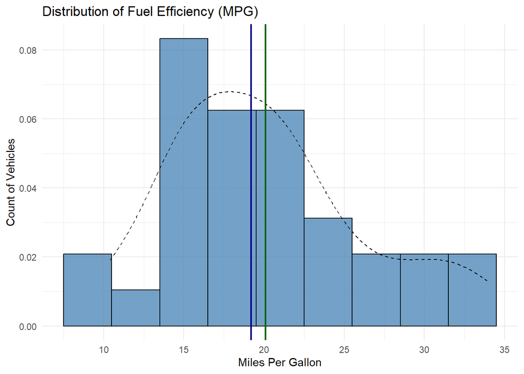

```r
# Distribution of MPG across all vehicles

mean_mpg <- mean(df$mpg)
median_mpg <- median(df$mpg)
df |>
    ggplot(aes(x = mpg)) +
    geom_histogram(
        aes(y = after_stat(density)),
        alpha = 0.75,
        binwidth = 3,
        fill = "steelblue",
        color = "black"
    ) +
    geom_density(linetype = "dashed") +
    geom_vline(xintercept = mean_mpg, color="darkgreen", linewidth = 0.75) +
    geom_vline(xintercept = median_mpg, color="darkblue", linewidth = 0.75) +
    labs(
        title = "Distribution of Fuel Efficiency (MPG)",
        x = "Miles Per Gallon",
        y = "Count of Vehicles"
    ) +
    theme_minimal()
```

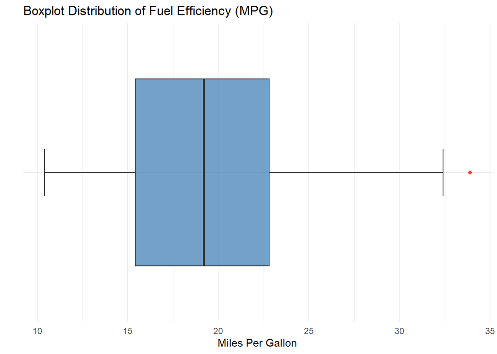

```r
# Boxplot of MPG across all vehicles

df |>
    ggplot(aes(x = mpg, y = "")) +
    geom_boxplot(
        alpha = 0.75,
        fill = "steelblue",
        staplewidth = 0.25,
        outlier.color = "red",
        outlier.shape = 16
    ) +
    labs(
        title = "Boxplot Distribution of Fuel Efficiency (MPG)",
        x = "Miles Per Gallon",
        y = ""
    ) +
    theme_minimal()
```

```r
# Detailed summary statistics of vehicles' MPG

df |>
    summarize(
        mean_mpg = mean(mpg),
        median_mpg = median(mpg),
        min_mpg = min(mpg),
        max_mpg = max(mpg),
        sd_mpg = sd(mpg),
        iqr_mpg = IQR(mpg)
    )
```

```
##   mean_mpg median_mpg min_mpg max_mpg   sd_mpg iqr_mpg
## 1 20.09062       19.2    10.4    33.9 6.026948   7.375
```

```r
df |>
    summarize(
        mean_mpg = mean(mpg),
        median_mpg = median(mpg),
        mean_wt = mean(wt) * 1000,
        mean_hp = mean(hp)
    )
```

```
##   mean_mpg median_mpg mean_wt  mean_hp
## 1 20.09062       19.2 3217.25 146.6875
```

Q: What are the *best* and *worst* cars?

```r
# Top 3 cars based on MPG

df |>
    arrange(desc(mpg)) |>
    slice_head(n = 3)
```

```
##            model  mpg cyl disp hp drat    wt  qsec       vs     am gear carb  brand origin
## 1 Toyota Corolla 33.9   4 71.1 65 4.22 1.835 19.90 Straight Manual    4    1 Toyota  Japan
## 2       Fiat 128 32.4   4 78.7 66 4.08 2.200 19.47 Straight Manual    4    1   Fiat Europe
## 3    Honda Civic 30.4   4 75.7 52 4.93 1.615 18.52 Straight Manual    4    2  Honda  Japan
```

```r
# Bottom 3 cars based on MPG

df |>
    arrange(mpg) |>
    slice_head(n = 3)
```

```
##                 model  mpg cyl disp  hp drat    wt  qsec       vs        am gear carb    brand        origin
## 1  Cadillac Fleetwood 10.4   8  472 205 2.93 5.250 17.98 V-shaped Automatic    3    4 Cadillac United States
## 2 Lincoln Continental 10.4   8  460 215 3.00 5.424 17.82 V-shaped Automatic    3    4  Lincoln United States
## 3          Camaro Z28 13.3   8  350 245 3.73 3.840 15.41 V-shaped Automatic    3    4   Camaro United States
```

Looking at vehicles in their brand and region of origin.

```r
# Car brands

summary(df$brand)
```

```
##      AMC Cadillac   Camaro Chrysler   Datsun    Dodge  Ferrari     Fiat     Ford    Honda  Lincoln    Lotus Maserati    Mazda Mercedes
##        2        1        1        1        1        2        1        2        1        1        1        1        1        2        7
## Plymouth  Pontiac  Porsche   Toyota    Volvo
##        2        1        1        2        1
```

```r
# Region of origin

summary(df$origin)
```

```
##        Europe         Japan United States
##            14             6            12
```

# 6 Check Relationships – Bivariate and Multivariate Analysis

Q: How fuel efficiency is related to weight (wt), horsepower (hp), and displacement (disp)?

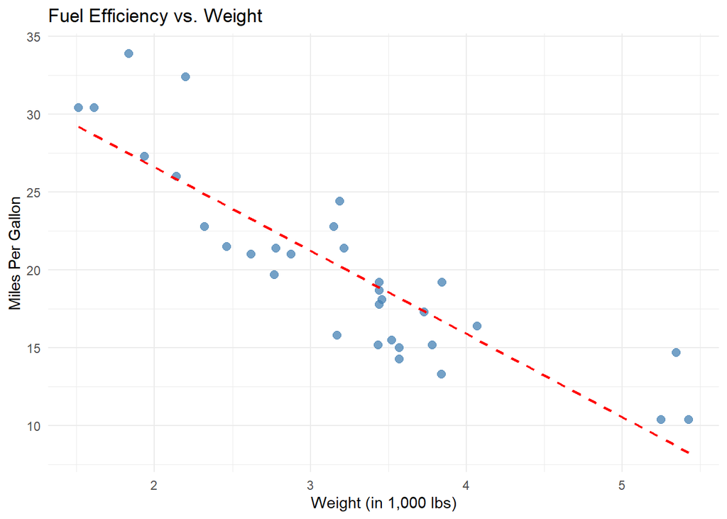

```r
# MPG vs. weight

df |>
    ggplot(aes(x = wt, y = mpg)) +
    geom_point(size = 2.5, alpha = 0.75, color = "steelblue") +
    # Trendline
    geom_smooth(
        method = "lm",
        color = "red",
        se = FALSE,
        linetype = "dashed",
        linewidth = 0.75
    ) +
    labs(
        title = "Fuel Efficiency vs. Weight",
        x = "Weight (in 1,000 lbs)",
        y = "Miles Per Gallon"
    ) +
    theme_minimal()
```

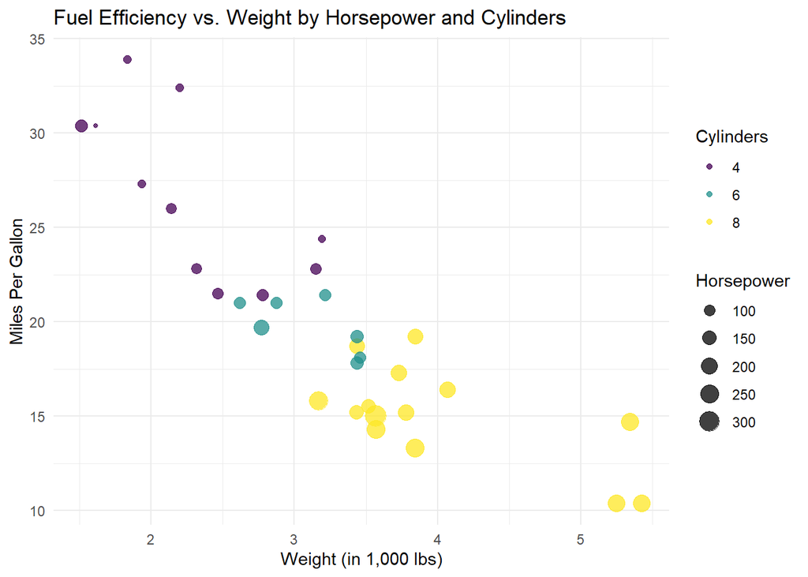

```r
# MPG vs. weight by horsepower and number of cylinders

df |>
    ggplot(aes(x = wt, y = mpg, color = cyl, size = hp)) +
    geom_point(alpha = 0.75) +
    scale_color_viridis_d(option = "viridis", name = "Cylinders") +
    labs(
        title = "Fuel Efficiency vs. Weight by Horsepower and Cylinders",
        x = "Weight (in 1,000 lbs)",
        y = "Miles Per Gallon",
        size = "Horsepower"
    ) +
    theme_minimal()
```

```r
# Correlation for key numeric variables

cor_mat <- df |>
    select(where(is.numeric)) |>
    cor(use = "complete.obs")

cor_mat
```

```
##             mpg       disp         hp        drat         wt        qsec
## mpg   1.0000000 -0.8475514 -0.7761684  0.68117191 -0.8676594  0.41868403
## disp -0.8475514  1.0000000  0.7909486 -0.71021393  0.8879799 -0.43369788
## hp   -0.7761684  0.7909486  1.0000000 -0.44875912  0.6587479 -0.70822339
## drat  0.6811719 -0.7102139 -0.4487591  1.00000000 -0.7124406  0.09120476
## wt   -0.8676594  0.8879799  0.6587479 -0.71244065  1.0000000 -0.17471588
## qsec  0.4186840 -0.4336979 -0.7082234  0.09120476 -0.1747159  1.00000000
```

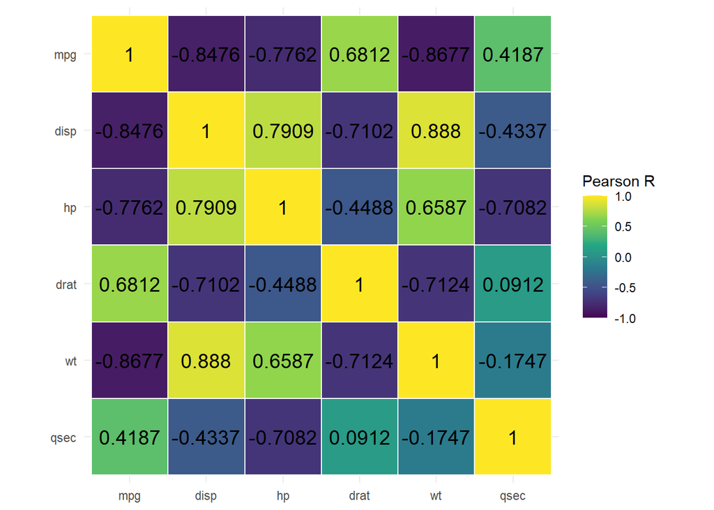

```r
cor_df <- cor_mat |>
    as.data.frame() |>
    rownames_to_column("var1") |>
    pivot_longer(-var1, names_to = "var2", values_to = "corr") |>
    mutate(across(c(var1, var2), fct_inorder))

cor_df |>
    ggplot(aes(x = var1, y = var2, fill = corr)) +
    geom_tile(color = "white", linewidth = 0.5) +
    geom_text(aes(label = round(corr, 4)), color = "black", size = 5) +
    scale_fill_viridis_c(
        limits = c(-1, 1),
        name = "Pearson R"
    ) +
    scale_y_discrete(limits = rev) +
    coord_fixed() +
    theme_minimal() +
    labs(
        x = NULL,
        y = NULL
    )
```

Based on the correlation matrix, check if `mpg`, `disp`, and `hp` are consistently strongly correlated.

```r
df |> group_by(am) |> summarize(correlation = cor(mpg, disp))
```

```
## # A tibble: 2 × 2
##   am        correlation
##   <fct>           <dbl>
## 1 Automatic      -0.793
## 2 Manual         -0.835
```

```r
df |> group_by(am) |> summarize(correlation = cor(mpg, hp))
```

```
## # A tibble: 2 × 2
##   am        correlation
##   <fct>           <dbl>
## 1 Automatic      -0.832
## 2 Manual         -0.801
```

```r
df |> group_by(am) |> summarize(correlation = cor(hp, disp))
```

```
## # A tibble: 2 × 2
##   am        correlation
##   <fct>           <dbl>
## 1 Automatic       0.834
## 2 Manual          0.924
```

```r
df |> group_by(cyl) |> summarize(correlation = cor(mpg, disp))
```

```
## # A tibble: 3 × 2
##   cyl   correlation
##   <ord>       <dbl>
## 1 4          -0.805
## 2 6           0.103
## 3 8          -0.520
```

```r
df |> group_by(cyl) |> summarize(correlation = cor(mpg, hp))
```

```
## # A tibble: 3 × 2
##   cyl   correlation
##   <ord>       <dbl>
## 1 4          -0.524
## 2 6          -0.127
## 3 8          -0.284
```

```r
df |> group_by(cyl) |> summarize(correlation = cor(hp, disp))
```

```
## # A tibble: 3 × 2
##   cyl   correlation
##   <ord>       <dbl>
## 1 4           0.435
## 2 6          -0.514
## 3 8           0.118
```

```r
df |> group_by(vs) |> summarize(correlation = cor(mpg, disp))
```

```
## # A tibble: 2 × 2
##   vs       correlation
##   <fct>          <dbl>
## 1 V-shaped      -0.812
## 2 Straight      -0.757
```

```r
df |> group_by(vs) |> summarize(correlation = cor(mpg, hp))
```

```
## # A tibble: 2 × 2
##   vs       correlation
##   <fct>          <dbl>
## 1 V-shaped      -0.648
## 2 Straight      -0.718
```

```r
df |> group_by(vs) |> summarize(correlation = cor(hp, disp))
```

```
## # A tibble: 2 × 2
##   vs       correlation
##   <fct>          <dbl>
## 1 V-shaped       0.568
## 2 Straight       0.603
```

# 7 Group Comparisons

Q: How manual and automatic vehicles differ in fuel efficiency?

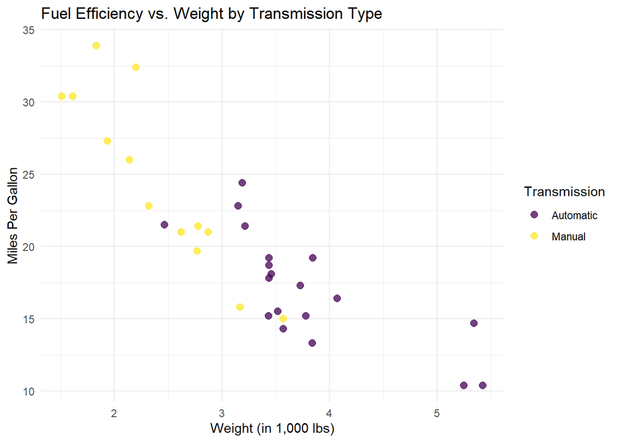

```r
# MPG vs. weight by transmission type

df |>
    ggplot(aes(x = wt, y = mpg, color = am)) +
    geom_point(size = 2.5, alpha = 0.75) +
    scale_color_viridis_d(name = "Transmission") +
    labs(
        title = "Fuel Efficiency vs. Weight by Transmission Type",
        x = "Weight (in 1,000 lbs)",
        y = "Miles Per Gallon"
    ) +
    theme_minimal()
```

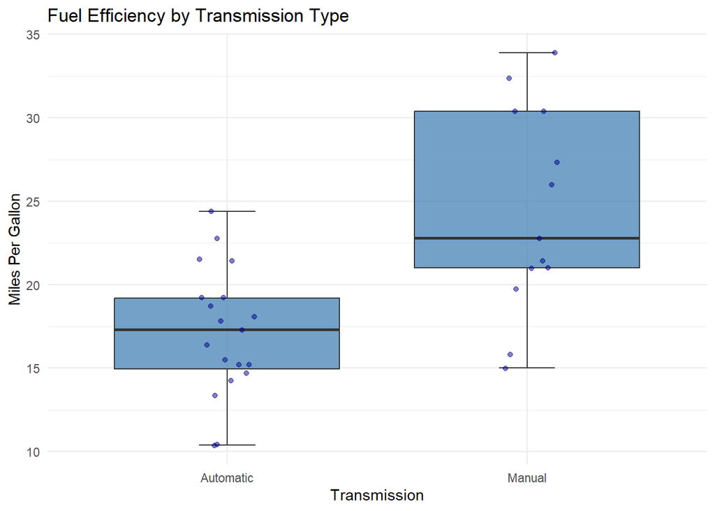

```r
# MPG across transmission type

df |>
    ggplot(aes(x = am, y = mpg, fill = am)) +
    geom_boxplot(
        alpha = 0.75,
        fill = "steelblue",
        staplewidth = 0.25,
        outlier.shape = 16
    ) +
    geom_jitter(
        width = 0.1,
        color = "darkblue",
        size = 1.5,
        alpha = 0.5
    ) +
    labs(
        title = "Fuel Efficiency by Transmission Type",
        x = "Transmission",
        y = "Miles Per Gallon"
    ) +
    theme_minimal() +
    theme(legend.position = "none")
```

Q: How do vehicles differ across engine type?

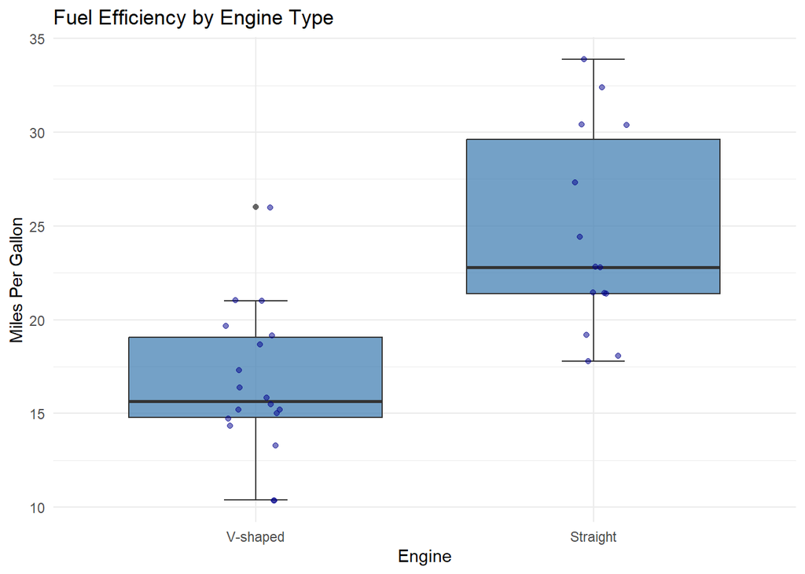

```r
# MPG across engine type

df |>
    ggplot(aes(x = vs, y = mpg, fill = vs)) +
    geom_boxplot(
        alpha = 0.75,
        fill = "steelblue",
        staplewidth = 0.25,
        outlier.shape = 16
    ) +
    geom_jitter(
        width = 0.1,
        color = "darkblue",
        size = 1.5,
        alpha = 0.5
    ) +
    labs(
        title = "Fuel Efficiency by Engine Type",
        x = "Engine",
        y = "Miles Per Gallon"
    ) +
    theme_minimal() +
    theme(legend.position = "none")
```

Q: How do vehicles differ across cylinder groups?

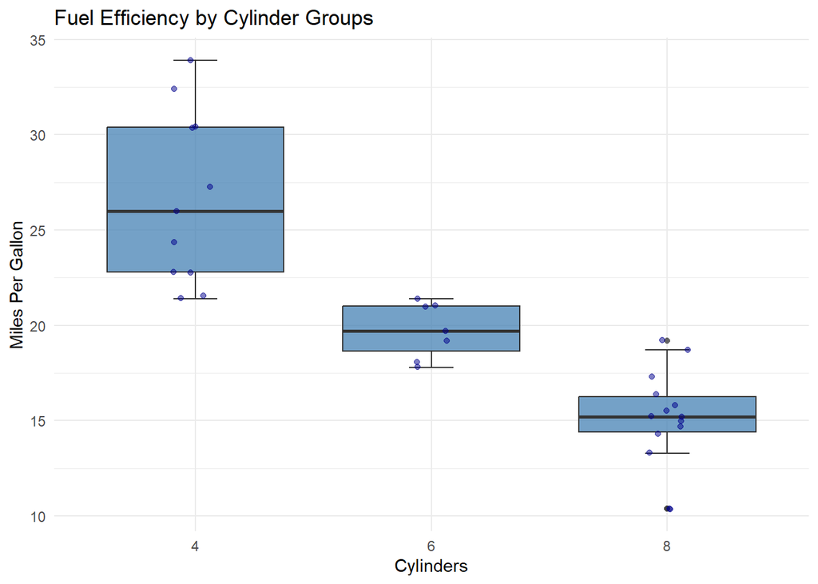

```r
# MPG across cylinder groups

df |>
    ggplot(aes(x = cyl, y = mpg, fill = cyl)) +
    geom_boxplot(
        alpha = 0.75,
        fill = "steelblue",
        staplewidth = 0.25,
        outlier.shape = 16
    ) +
    geom_jitter(
        width = 0.1,
        color = "darkblue",
        size = 1.5,
        alpha = 0.5
    ) +
    labs(
        title = "Fuel Efficiency by Cylinder Groups",
        x = "Cylinders",
        y = "Miles Per Gallon"
    ) +
    theme_minimal() +
    theme(legend.position = "none")
```

Q: How do vehicle differ across regions of origin?

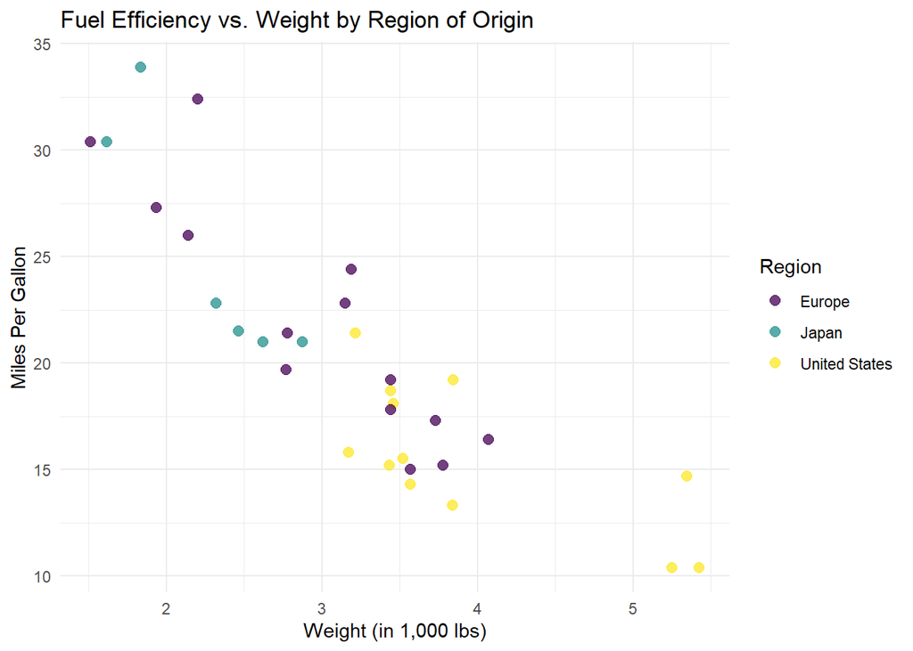

```r
# MPG vs. weight by region of origin

df |>
    ggplot(aes(x = wt, y = mpg, color = origin)) +
    geom_point(size = 2.5, alpha = 0.75) +
    scale_color_viridis_d(name = "Region") +
    labs(
        title = "Fuel Efficiency vs. Weight by Region of Origin",
        x = "Weight (in 1,000 lbs)",
        y = "Miles Per Gallon"
    ) +
    theme_minimal()
```

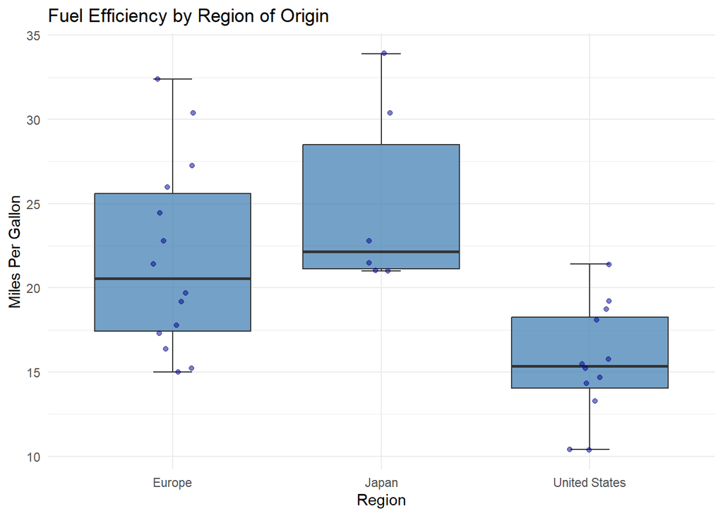

```r
# MPG across brands based on region of origin

df |>
    ggplot(aes(x = origin, y = mpg, fill = origin)) +
    geom_boxplot(
        alpha = 0.75,
        fill = "steelblue",
        staplewidth = 0.25,
        outlier.shape = 16
    ) +
    geom_jitter(
        width = 0.1,
        color = "darkblue",
        size = 1.5,
        alpha = 0.5
    ) +
    labs(
        title = "Fuel Efficiency by Region of Origin",
        x = "Region",
        y = "Miles Per Gallon"
    ) +
    theme_minimal() +
    theme(legend.position = "none")
```

View all the cars by their region of origin.

```r
# From United States

df |> filter(origin == "United States") |> select(-origin) |> arrange(desc(mpg))
```

```
##                  model  mpg cyl disp  hp drat    wt  qsec       vs        am gear carb    brand
## 1       Hornet 4 Drive 21.4   6  258 110 3.08 3.215 19.44 Straight Automatic    3    1    Dodge
## 2     Pontiac Firebird 19.2   8  400 175 3.08 3.845 17.05 V-shaped Automatic    3    2  Pontiac
## 3    Hornet Sportabout 18.7   8  360 175 3.15 3.440 17.02 V-shaped Automatic    3    2      AMC
## 4              Valiant 18.1   6  225 105 2.76 3.460 20.22 Straight Automatic    3    1 Plymouth
## 5       Ford Pantera L 15.8   8  351 264 4.22 3.170 14.50 V-shaped    Manual    5    4     Ford
## 6     Dodge Challenger 15.5   8  318 150 2.76 3.520 16.87 V-shaped Automatic    3    2    Dodge
## 7          AMC Javelin 15.2   8  304 150 3.15 3.435 17.30 V-shaped Automatic    3    2      AMC
## 8    Chrysler Imperial 14.7   8  440 230 3.23 5.345 17.42 V-shaped Automatic    3    4 Chrysler
## 9           Duster 360 14.3   8  360 245 3.21 3.570 15.84 V-shaped Automatic    3    4 Plymouth
## 10          Camaro Z28 13.3   8  350 245 3.73 3.840 15.41 V-shaped Automatic    3    4   Camaro
## 11  Cadillac Fleetwood 10.4   8  472 205 2.93 5.250 17.98 V-shaped Automatic    3    4 Cadillac
## 12 Lincoln Continental 10.4   8  460 215 3.00 5.424 17.82 V-shaped Automatic    3    4  Lincoln
```

```r
# From Europe

df |> filter(origin == "Europe") |> select(-origin) |> arrange(desc(mpg))
```

```
##              model  mpg cyl  disp  hp drat    wt  qsec       vs        am gear carb    brand
## 1         Fiat 128 32.4   4  78.7  66 4.08 2.200 19.47 Straight    Manual    4    1     Fiat
## 2     Lotus Europa 30.4   4  95.1 113 3.77 1.513 16.90 Straight    Manual    5    2    Lotus
## 3        Fiat X1-9 27.3   4  79.0  66 4.08 1.935 18.90 Straight    Manual    4    1     Fiat
## 4    Porsche 914-2 26.0   4 120.3  91 4.43 2.140 16.70 V-shaped    Manual    5    2  Porsche
## 5    Mercedes 240D 24.4   4 146.7  62 3.69 3.190 20.00 Straight Automatic    4    2 Mercedes
## 6     Mercedes 230 22.8   4 140.8  95 3.92 3.150 22.90 Straight Automatic    4    2 Mercedes
## 7       Volvo 142E 21.4   4 121.0 109 4.11 2.780 18.60 Straight    Manual    4    2    Volvo
## 8     Ferrari Dino 19.7   6 145.0 175 3.62 2.770 15.50 V-shaped    Manual    5    6  Ferrari
## 9     Mercedes 280 19.2   6 167.6 123 3.92 3.440 18.30 Straight Automatic    4    4 Mercedes
## 10   Mercedes 280C 17.8   6 167.6 123 3.92 3.440 18.90 Straight Automatic    4    4 Mercedes
## 11  Mercedes 450SL 17.3   8 275.8 180 3.07 3.730 17.60 V-shaped Automatic    3    3 Mercedes
## 12  Mercedes 450SE 16.4   8 275.8 180 3.07 4.070 17.40 V-shaped Automatic    3    3 Mercedes
## 13 Mercedes 450SLC 15.2   8 275.8 180 3.07 3.780 18.00 V-shaped Automatic    3    3 Mercedes
## 14   Maserati Bora 15.0   8 301.0 335 3.54 3.570 14.60 V-shaped    Manual    5    8 Maserati
```

```r
# From Japan

df |> filter(origin == "Japan") |> select(-origin) |> arrange(desc(mpg))
```

```
##            model  mpg cyl  disp  hp drat    wt  qsec       vs        am gear carb  brand
## 1 Toyota Corolla 33.9   4  71.1  65 4.22 1.835 19.90 Straight    Manual    4    1 Toyota
## 2    Honda Civic 30.4   4  75.7  52 4.93 1.615 18.52 Straight    Manual    4    2  Honda
## 3     Datsun 710 22.8   4 108.0  93 3.85 2.320 18.61 Straight    Manual    4    1 Datsun
## 4  Toyota Corona 21.5   4 120.1  97 3.70 2.465 20.01 Straight Automatic    3    1 Toyota
## 5      Mazda RX4 21.0   6 160.0 110 3.90 2.620 16.46 V-shaped    Manual    4    4  Mazda
## 6  Mazda RX4 Wag 21.0   6 160.0 110 3.90 2.875 17.02 V-shaped    Manual    4    4  Mazda
```

# 8 Statistical Testing

Definitions:

- $H_o$ (Null Hypothesis) - no effect, no difference, or no relationship in a population; status quo, zero effect, random chance
- $H_1$ (Alternative Hypothesis) - a real effect, difference, or relationship does exist; expected outcome

If the p-value is below the chosen significance level, such as 0.05, reject the null hypothesis.

## 8.1 Weight and MPG

Q: Is vehicle weight significantly correlated with fuel efficiency?

- $H_o$: No linear correlation between weight and MPG.
- $H_1$: Linear correlation exists between weight and MPG.

```r
cor.test(df$wt, df$mpg, method = "pearson")
```

```
##
##  Pearson's product-moment correlation
##
## data:  df$wt and df$mpg
## t = -9.559, df = 30, p-value = 1.294e-10
## alternative hypothesis: true correlation is not equal to 0
## 95 percent confidence interval:
##  -0.9338264 -0.7440872
## sample estimates:
##        cor
## -0.8676594
```

Note: Statistical association does not automatically imply causation.

## 8.2 Transmission and MPG

Q: Do automatic and manual transmission cars have different fuel efficiencies?

- $H_o$: Mean MPG of automatic cars = Mean MPG of manual cars.
- $H_1$: Mean MPG of automatic cars != Mean MPG of manual cars.

```r
t.test(mpg ~ am, data = df, var.equal = FALSE)
```

```
##
##  Welch Two Sample t-test
##
## data:  mpg by am
## t = -3.7671, df = 18.332, p-value = 0.001374
## alternative hypothesis: true difference in means between group Automatic and group Manual is not equal to 0
## 95 percent confidence interval:
##  -11.280194  -3.209684
## sample estimates:
## mean in group Automatic    mean in group Manual
##                17.14737                24.39231
```

## 8.3 Engine Type and MPG

Q: Do each engine type have different fuel efficiencies?

- $H_o$: Mean MPG of cars with straight engine = Mean MPG of cars with v-shaped engine.
- $H_1$: Mean MPG of cars with straight engine != Mean MPG of cars with v-shaped engine.

```r
t.test(mpg ~ vs, data = df, var.equal = FALSE)
```

```
##
##  Welch Two Sample t-test
##
## data:  mpg by vs
## t = -4.6671, df = 22.716, p-value = 0.0001098
## alternative hypothesis: true difference in means between group V-shaped and group Straight is not equal to 0
## 95 percent confidence interval:
##  -11.462508  -4.418445
## sample estimates:
## mean in group V-shaped mean in group Straight
##               16.61667               24.55714
```

## 8.4 Cylinder Count and MPG

Q: Do each cylinder groups have different fuel efficiencies?

- $H_o$: All cylinder groups have the same population mean MPG.
- $H_1$: At least one cylinder group has a different population mean MPG.

```r
result_anova_cyl = aov(mpg ~ cyl, data = df)
summary(result_anova_cyl)
```

```
##             Df Sum Sq Mean Sq F value   Pr(>F)
## cyl          2  824.8   412.4    39.7 4.98e-09 ***
## Residuals   29  301.3    10.4
## ---
## Signif. codes:  0 '***' 0.001 '**' 0.01 '*' 0.05 '.' 0.1 ' ' 1
```

```r
# ANOVA is statistically significant thus perform pairwise comparisons
TukeyHSD(result_anova_cyl)
```

```
##   Tukey multiple comparisons of means
##     95% family-wise confidence level
##
## Fit: aov(formula = mpg ~ cyl, data = df)
##
## $cyl
##           diff        lwr        upr     p adj
## 6-4  -6.920779 -10.769350 -3.0722086 0.0003424
## 8-4 -11.563636 -14.770779 -8.3564942 0.0000000
## 8-6  -4.642857  -8.327583 -0.9581313 0.0112287
```

## 8.5 Origin and MPG

Q: Is there a significant difference in the car’s performance based where their brand originated?

- $H_o$: All regions have the same population mean MPG.
- $H_1$: At least one region has a different population mean MPG.

```r
result_anova_origin = aov(mpg ~ origin, data = df)
summary(result_anova_origin)
```

```
##             Df Sum Sq Mean Sq F value   Pr(>F)
## origin       2  435.6  217.80   9.148 0.000831 ***
## Residuals   29  690.4   23.81
## ---
## Signif. codes:  0 '***' 0.001 '**' 0.01 '*' 0.05 '.' 0.1 ' ' 1
```

```r
# ANOVA is statistically significant thus perform pairwise comparisons
TukeyHSD(result_anova_origin)
```

```
##   Tukey multiple comparisons of means
##     95% family-wise confidence level
##
## Fit: aov(formula = mpg ~ origin, data = df)
##
## $origin
##                           diff        lwr       upr     p adj
## Japan-Europe          3.292857  -2.587127  9.172841 0.3627212
## United States-Europe -6.223810 -10.964404 -1.483215 0.0081237
## United States-Japan  -9.516667 -15.541858 -3.491476 0.0014755
```

# 9 Additional investigation

## 9.1 Over-performing Cars

Management wants to know if there are vehicles whose fuel efficiency is surprising given their size or power. To find out, we can fit a linear model predicting `mpg` based on `wt` and `hp`, and look at the residuals (the difference between the expected MPG and actual MPG).

```r
# Fit a model predicting MPG using Weight and Horsepower
eff_model <- lm(mpg ~ wt + hp, data = df)
summary(eff_model)
```

```
##
## Call:
## lm(formula = mpg ~ wt + hp, data = df)
##
## Residuals:
##    Min     1Q Median     3Q    Max
## -3.941 -1.600 -0.182  1.050  5.854
##
## Coefficients:
##             Estimate Std. Error t value Pr(>|t|)
## (Intercept) 37.22727    1.59879  23.285  < 2e-16 ***
## wt          -3.87783    0.63273  -6.129 1.12e-06 ***
## hp          -0.03177    0.00903  -3.519  0.00145 **
## ---
## Signif. codes:  0 '***' 0.001 '**' 0.01 '*' 0.05 '.' 0.1 ' ' 1
##
## Residual standard error: 2.593 on 29 degrees of freedom
## Multiple R-squared:  0.8268, Adjusted R-squared:  0.8148
## F-statistic: 69.21 on 2 and 29 DF,  p-value: 9.109e-12
```

```r
# Attach predictions and residuals to our data
cars_analyzed <- augment(eff_model, data = df)
cars_analyzed |> head(5)
```

```
## # A tibble: 5 × 20
##   model     mpg cyl    disp    hp  drat    wt  qsec vs    am    gear  carb  brand origin .fitted .resid   .hat .sigma .cooksd .std.resid
##   <fct>   <dbl> <ord> <dbl> <dbl> <dbl> <dbl> <dbl> <fct> <fct> <ord> <ord> <fct> <fct>    <dbl>  <dbl>  <dbl>  <dbl>   <dbl>      <dbl>
## 1 Mazda …  21   6       160   110  3.9   2.62  16.5 V-sh… Manu… 4     4     Mazda Japan     23.6 -2.57  0.0443   2.59 1.59e-2    -1.01
## 2 Mazda …  21   6       160   110  3.9   2.88  17.0 V-sh… Manu… 4     4     Mazda Japan     22.6 -1.58  0.0405   2.62 5.46e-3    -0.623
## 3 Datsun…  22.8 4       108    93  3.85  2.32  18.6 Stra… Manu… 4     1     Dats… Japan     25.3 -2.48  0.0602   2.59 2.07e-2    -0.985
## 4 Hornet…  21.4 6       258   110  3.08  3.22  19.4 Stra… Auto… 3     1     Dodge Unite…    21.3  0.135 0.0475   2.64 4.72e-5     0.0533
## 5 Hornet…  18.7 8       360   175  3.15  3.44  17.0 V-sh… Auto… 3     2     AMC   Unite…    18.3  0.373 0.0369   2.64 2.74e-4     0.146
```

```r
# Find the biggest over-performers (positive residuals)
over_performing_cars = cars_analyzed |>
    arrange(desc(.resid)) |>
    pull(model) |>
    head(3)

df |> filter(model %in% over_performing_cars) |> arrange(desc(mpg))
```

```
##               model  mpg cyl  disp  hp drat    wt  qsec       vs        am gear carb    brand        origin
## 1    Toyota Corolla 33.9   4  71.1  65 4.22 1.835 19.90 Straight    Manual    4    1   Toyota         Japan
## 2          Fiat 128 32.4   4  78.7  66 4.08 2.200 19.47 Straight    Manual    4    1     Fiat        Europe
## 3 Chrysler Imperial 14.7   8 440.0 230 3.23 5.345 17.42 V-shaped Automatic    3    4 Chrysler United States
```

- A large positive residual means a car gets much better fuel economy than its weight and horsepower suggest it should.

## 9.2 Regional Advantage

We created a boxplot before showing the fuel efficiency of cars by region of origin. At a glance, Japanese cars has the highest MPG followed by European cars then US cars. We also determined through an ANOVA test that difference in fuel efficiency between European and Japanese cars compared to US cars is significant.

Let’s further verify if Japanese or European manufacturers demonstrate inherently better fuel efficiency than US models, even when strictly controlling for vehicle weight i.e. assuming the vehicle weights the same.

```r
# Set the United States as the baseline comparison
df_reg_origin_US = df |> mutate(origin = fct_relevel(origin, "United States"))

# Fit a model then check coefficient for baseline fuel efficiency difference
region_model <- lm(mpg ~ wt + origin, data = df_reg_origin_US)
summary(region_model)
```

```
##
## Call:
## lm(formula = mpg ~ wt + origin, data = df_reg_origin_US)
##
## Residuals:
##     Min      1Q  Median      3Q     Max
## -3.8754 -2.4991 -0.1575  1.8702  6.7269
##
## Coefficients:
##              Estimate Std. Error t value Pr(>|t|)
## (Intercept)   35.2295     3.1032  11.353 5.45e-12 ***
## wt            -4.9618     0.7504  -6.612 3.58e-07 ***
## originEurope   1.3595     1.4251   0.954    0.348
## originJapan    1.2247     1.9948   0.614    0.544
## ---
## Signif. codes:  0 '***' 0.001 '**' 0.01 '*' 0.05 '.' 0.1 ' ' 1
##
## Residual standard error: 3.103 on 28 degrees of freedom
## Multiple R-squared:  0.7606, Adjusted R-squared:  0.735
## F-statistic: 29.66 on 3 and 28 DF,  p-value: 7.744e-09
```

- European and Japanese cars only has an advantage of 1.2 to 1.3 MPG more than US cars, which is statisfically insignificant as shown from the p-values.
- This result suggests that there isn’t much advantage in choosing parts (e.g. engine) from one region over another and it supports the idea that making the vehicle lighter improves fuel efficiency.

## 9.3 Drivetrain Complexity vs. Acceleration

Does increasing the number of forward gears or carburetors significantly improve a vehicle’s 1/4 mile time without severely penalizing its fuel efficiency?

```r
# Model acceleration based on drivetrain complexity
acceleration_model <- lm(qsec ~ gear + carb, data = df)
summary(acceleration_model)
```

```
##
## Call:
## lm(formula = qsec ~ gear + carb, data = df)
##
## Residuals:
##     Min      1Q  Median      3Q     Max
## -1.3615 -0.7880 -0.0691  0.5967  3.7490
##
## Coefficients:
##             Estimate Std. Error t value Pr(>|t|)
## (Intercept)  17.2630     0.3418  50.509  < 2e-16 ***
## gear.L       -1.1135     0.5790  -1.923  0.06642 .
## gear.Q       -1.5275     0.4483  -3.407  0.00232 **
## carb.L       -2.0943     1.1578  -1.809  0.08302 .
## carb.Q        0.2999     0.8770   0.342  0.73535
## carb.C       -0.2017     0.8769  -0.230  0.82001
## carb^4       -0.3123     0.9121  -0.342  0.73501
## carb^5       -0.4740     0.6831  -0.694  0.49438
## ---
## Signif. codes:  0 '***' 0.001 '**' 0.01 '*' 0.05 '.' 0.1 ' ' 1
##
## Residual standard error: 1.236 on 24 degrees of freedom
## Multiple R-squared:  0.6295, Adjusted R-squared:  0.5214
## F-statistic: 5.825 on 7 and 24 DF,  p-value: 0.0004961
```

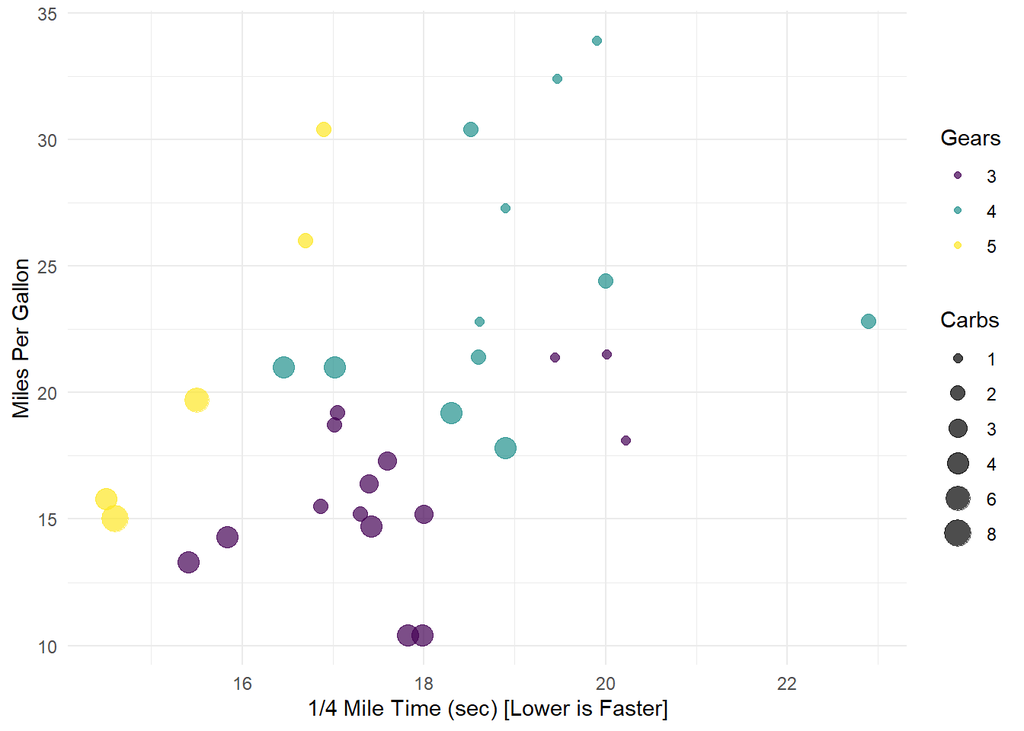

```r
# Visualize the trade-off (qsec vs mpg) mapped with complexity
df |>
    ggplot(aes(x = qsec, y = mpg, color = gear, size = carb)) +
    geom_point(alpha = 0.7) +
    labs(
        x = "1/4 Mile Time (sec) [Lower is Faster]",
        y = "Miles Per Gallon",
        color = "Gears",
        size = "Carbs"
    ) +
    theme_minimal()
```

- The overall p-value confirms that the effect of gears and carburetors on acceleration is not zero. It proves the relationship is valid.
- However the Adjusted R-squared indicates that nearly half of the variance in a vehicle’s 1/4 mile time remains entirely unexplained by this specific model.
- Based on the data, if the goal is to build a faster car, relying on drivetrain complexity (gear and carb) is a valid but practically weak strategy compared to the approach of increasing horsepower and reducing chassis weight.

# 10 Summary

## 10.1 Key findings

1. There is a strong negative correlation between a vehicle’s weight and its fuel efficiency. Across all vehicle types, as weight increases, MPG predictably and sharply declines.
2. While manual transmission vehicles show a statistically higher baseline MPG, this advantage is heavily conflated with vehicle size. Manual cars in the 1970s tend to be lighter with smaller engines, meaning the transmission alone doesn’t account for the entire efficiency gain.
3. High horsepower generally results in lower fuel efficiency. However, regression modeling reveals clear “overperforming” outliers—specific vehicles that achieve significantly higher MPG than their weight and horsepower profiles dictate.

## 10.2 Recommendations

1. Prioritize lightweight engineering for eco-models - Shift R&D investment toward reducing chassis and component weight rather than solely relying on engine tuning.
2. Reverse-engineer the market’s overperformers - Conduct a competitive tear-down of the specific vehicles identified with high positive residuals in the multivariate model. The residual analysis proves certain vehicles beat the expected performance-to-efficiency trade-off, suggesting unmeasured factors (like aerodynamics or gearing) that the manufacturer should replicate.
3. Target the high-efficiency segment with lightweight manual configurations - If launching a new fuel-conscious line-up based on this data, pair manual transmissions exclusively with lighter frames. Statistical testing confirms that the manual transmission group dominates the highest end of the MPG distribution.

## 10.3 Limitations

Given the relevant period of the dataset and its size (32 observations), the derived insights are limited and may no longer be applicable in today’s market. It is further recommended to redo this analysis using a larger and updated dataset.